# **Flight Booking Prediction**

#### **For Laptop**

```python
# using function BaggingClassifier from sklearn to build model
bagging_l =BaggingClassifier(random_state=1)
bagging_l.fit(X_l_train, y_l_train)
```

```
BaggingClassifier(random_state=1)
```

##### **Confusion Matrix and Performance Check of Testing data - For Laptop**

```
Testing performance
    Accuracy    Recall  Precision        F1   ROC_AUC
0  0.938144  0.835165   0.808511  0.821622  0.897243
```

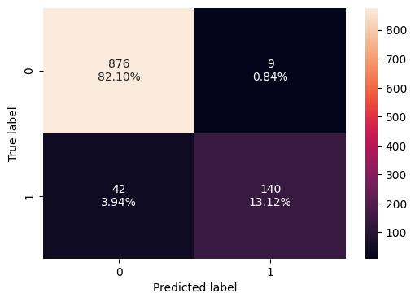

```python
#create a confusion matrix of the classifier's performance on the testing data
confusion_matrix_sklearn(bagging_l, X_l_test, y_l_test)

bagging_model_test_perf_l = model_performance_classification_sklearn(dtree_l, X_l_test, y_l_test)
print("Testing performance \n",bagging_model_test_perf_l)
```

**Observations:**

##### **Confusion Matrix and Performance Check of Training data - For Laptop**

```
Training performance
    Accuracy  Recall  Precision   F1  ROC_AUC
0       1.0     1.0        1.0  1.0      1.0
```

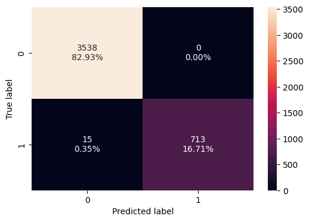

```python
#create a confusion matrix of the classifier's performance on the training data
confusion_matrix_sklearn(bagging_l, X_l_train, y_l_train)

bagging_model_train_perf_l = model_performance_classification_sklearn(dtree_l, X_l_train, y_l_train)
print("Training performance \n",bagging_model_train_perf_l)
```

**Observations:**

##### **Bagging Classifier with Hyperparameter Tuning - For Laptop**

```python
# choosing type of classifier

tuning_bagging_l =BaggingClassifier(random_state=1)

# form grid of parameters to search in
grid_para ={
    "max_samples": [0.7, 0.8, 0.9, 1.0],
    "max_features": [0.7, 0.8, 0.9, 1.0],
    "n_estimators": np.arange(50, 100, 10), }

# setting type of score used to evaluate performance search
scorer = make_scorer(f1_score)

# runing GridSearch
grid_obj =GridSearchCV(tuning_bagging_l, grid_para, scoring=scorer, cv=5)
grid_obj =grid_obj.fit(X_m_train, y_m_train)

# setting classifer to best combination of parameters
tuning_bagging_l =grid_obj.best_estimator_

# fitting best decision tree to training data
tuning_bagging_l.fit(X_l_train, y_l_train)
BaggingClassifier(max_features=0.7, max_samples=0.7, n_estimators=60, random_state=1)
```

```
BaggingClassifier(max_features=0.7, max_samples=0.7, n_estimators=60,
                  random_state=1)
```

##### **Confusion Matrix and Performance Check After Tuning - For Laptop**

```
Testing performance
    Accuracy    Recall  Precision        F1   ROC_AUC
0  0.969072  0.846154   0.968553  0.903226  0.994102
```

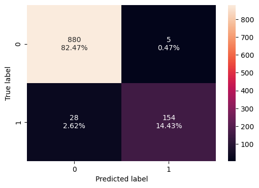

```python
#create a confusion matrix of the classifier's performance on the testing data
confusion_matrix_sklearn(tuning_bagging_l, X_l_test,y_l_test)

tuned_bagging_model_test_perf_l = model_performance_classification_sklearn(tuning_bagging_l, X_l_test, y_l_test)
print("Testing performance \n",tuned_bagging_model_test_perf_l)
```

**Observations:**

1. Outstanding overall performance (Accuracy ≈ 0.97).
2. Very high Precision ≈ 0.97, meaning almost every user predicted as a buyer actually buys a ticket.
3. High Recall ≈ 0.85, so most real laptop buyers are successfully captured.
4. Confusion matrix shows 154 real buyers correctly identified, with only 5 non-buyers wrongly predicted as buyers.
5. ROC-AUC ≈ 0.99, indicating excellent separation between buyers and non-buyers.

```python
#create a confusion matrix of the classifier's performance on the training data
confusion_matrix_sklearn(tuning_bagging_l, X_l_train,y_l_train)

tuned_bagging_model_train_perf_l = model_performance_classification_sklearn(tuning_bagging_l, X_l_train, y_l_train)
print("Training performance \n",tuned_bagging_model_train_perf_l)
```

[output not shown]

```
Training performance
    Accuracy  Recall  Precision   F1  ROC_AUC
0       1.0     1.0        1.0  1.0      1.0
```

**Observations:**

### **Random Forest Classifier**

#### **For Mobile**

```python
# using function RandomForestClassifier from sklearn to build model
random_forest_m =RandomForestClassifier(random_state=1)
random_forest_m.fit(X_m_train, y_m_train)
```

```
RandomForestClassifier(random_state=1)
```

##### **Confusion Matrix and Performance Check of Testing data - For Mobile**

```
Testing performance
    Accuracy    Recall  Precision        F1   ROC_AUC
0  0.960987  0.748718        1.0  0.856305  0.986597
```

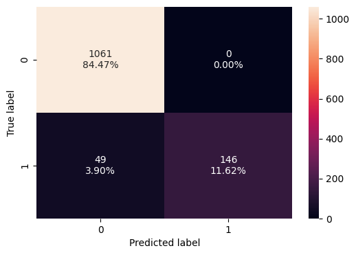

```python
#create a confusion matrix of the classifier's performance on the testing data
confusion_matrix_sklearn(random_forest_m, X_m_test, y_m_test)

random_forest_test_perf_m= model_performance_classification_sklearn(random_forest_m, X_m_test, y_m_test)
print("Testing performance \n",random_forest_test_perf_m)
```

**Observations:**

1. Very strong overall performance (Accuracy ≈ 0.96).
2. Perfect Precision = 1.0, meaning every user predicted as a buyer actually bought a ticket (no false positives).
3. Recall ≈ 0.75, so most real mobile buyers are captured, though a few are missed.
4. Confusion matrix shows 146 real buyers correctly identified and 0 non-buyers wrongly predicted as buyers.
5. ROC-AUC ≈ 0.99, indicating excellent separation between buyers and non-buyers.

##### **Confusion Matrix and Performance Check of Training data - For Mobile**

```
Training performance
    Accuracy  Recall  Precision   F1  ROC_AUC
0       1.0     1.0        1.0  1.0      1.0
```

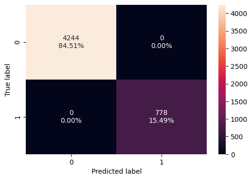

```python
#create a confusion matrix of the classifier's performance on the training data
confusion_matrix_sklearn(random_forest_m, X_m_train, y_m_train)

random_forest_train_perf_m = model_performance_classification_sklearn(random_forest_m, X_m_train, y_m_train)
print("Training performance \n",random_forest_train_perf_m)
```

**Observations:**

1. Perfect training performance (Accuracy, Precision, Recall, F1, ROC-AUC = 1.0).
2. Confusion matrix shows no misclassifications.
3. Indicates strong fitting.
4. Excellent test performance confirms the model generalizes very well.
5. Training results support the robustness of the model.

##### **Random Forest With Hyperparameter Tuning - For Mobile**

```python
# # choosing type of classifier
tuning_random_forest_m =RandomForestClassifier(random_state= 1)

# form grid of parameters to search in
grid_para ={
    "class_weight": ["balanced", None],
    "max_samples": [0.7, 0.8, 0.9, 1.0],
    "max_depth": np.arange(1, 5, 1),
    "max_features": ["sqrt", "log2"],
    "min_samples_split": [50, 100, 150, 200],
    "n_estimators": np.arange(20, 100, 20), }

# setting type of score used to evaluate performance search
scorer = make_scorer(f1_score)

# runing GridSearch
grid_obj =GridSearchCV(tuning_random_forest_m, grid_para, scoring=scorer, cv =5)
grid_obj =grid_obj.fit(X_m_train, y_m_train)

# setting classifer to best combination of parameters
tuning_random_forest_m =grid_obj.best_estimator_

# fitting best decision tree to training data

tuning_random_forest_m.fit(X_m_train, y_m_train)
```

```
RandomForestClassifier(class_weight='balanced', max_depth=np.int64(4),
                       max_samples=0.7, min_samples_split=50,
                       n_estimators=np.int64(80), random_state=1)
```

##### **Confusion Matrix and Performance Check After Tuning - For Mobile**

```
Testing performance
    Accuracy    Recall  Precision        F1   ROC_AUC
0  0.771497  0.702564   0.374317  0.488414  0.827154
```

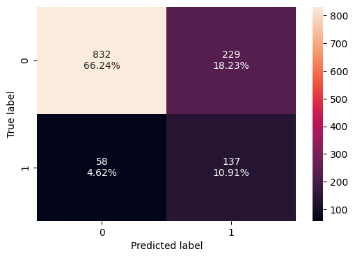

```python
#create a confusion matrix of the classifier's performance on the testing data
confusion_matrix_sklearn(tuning_random_forest_m, X_m_test,y_m_test)

tuned_random_forest_model_test_perf_m = model_performance_classification_sklearn(tuning_random_forest_m, X_m_test, y_m_test)
print("Testing performance \n",tuned_random_forest_model_test_perf_m)
```

**Observations:**

1. Moderate overall accuracy (~77%), showing reasonable prediction performance.
2. Precision ≈ 0.37 → when the model predicts a mobile user will buy a ticket, it is correct only about 1 out of 3 times (many false positives).
3. Recall ≈ 0.70 → the model is able to identify most actual buyers, which is good for capturing potential customers.
4. Confusion matrix shows 137 true buyers correctly predicted, but 229 non-buyers wrongly predicted as buyers.
5. ROC-AUC ≈ 0.83, indicating good class separation, though weaker than the untuned model.

```
Training performance
    Accuracy    Recall  Precision        F1   ROC_AUC
0  0.762644  0.695373   0.361631  0.475814  0.813568
```

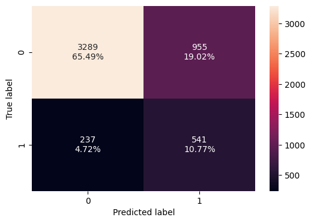

```python
#create a confusion matrix of the classifier's performance on the training data
confusion_matrix_sklearn(tuning_random_forest_m, X_m_train,y_m_train)

tuned_random_forest_model_train_perf_m = model_performance_classification_sklearn(tuning_random_forest_m, X_m_train, y_m_train)
print("Training performance \n",tuned_random_forest_model_train_perf_m)
```

**Observations:**

1. Accuracy ≈ 76%, close to test performance → no severe overfitting.
2. Precision ≈ 0.36, still relatively low, confirming false positives remain an issue.
3. Recall ≈ 0.70, consistently captures a majority of real buyers.
4. Confusion matrix shows many correct buyer predictions, but also a noticeable number of false alerts.
5. ROC-AUC ≈ 0.81, showing stable but moderate discrimination.

#### **For Laptop**

```python
# using function RandomForestClassifier from sklearn to build model
random_forest_l =RandomForestClassifier(random_state=1)
random_forest_l.fit(X_l_train, y_l_train)
```

```
RandomForestClassifier(random_state=1)
```

##### **Confusion Matrix and Performance Check of Testing data - For Laptop**

```
Testing performance
    Accuracy    Recall  Precision        F1   ROC_AUC
0  0.961575  0.785714   0.986207  0.874618  0.993956
```

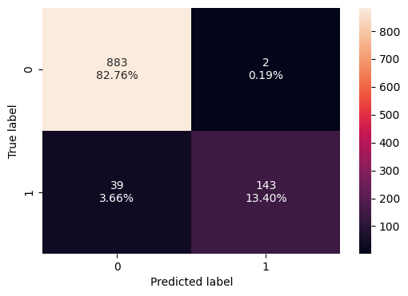

```python
#create a confusion matrix of the classifier's performance on the testing data
confusion_matrix_sklearn(random_forest_l, X_l_test, y_l_test)

random_forest_test_perf_l = model_performance_classification_sklearn(random_forest_l, X_l_test, y_l_test)
print("Testing performance \n",random_forest_test_perf_l)
```

**Observations:**

1. Very high accuracy (~96%), showing strong overall prediction performance.
2. Precision ≈ 0.99 → when the model predicts a laptop user will buy a ticket, it is almost always correct.
3. Recall ≈ 0.79 → the model correctly identifies most actual buyers, with very few missed.
4. Confusion matrix shows 143 true buyers correctly predicted and only 2 false positives, indicating excellent reliability.
5. ROC-AUC ≈ 0.99, showing excellent class separation between buyers and non-buyers.

##### **Confusion Matrix and Performace Check of Training data - For Laptop**

```python
#create a confusion matrix of the classifier's performance on the training data
confusion_matrix_sklearn(random_forest_l, X_l_train, y_l_train)

random_forest_train_perf_l = model_performance_classification_sklearn(random_forest_l, X_l_train, y_l_train)
print("Training performance \n",random_forest_train_perf_l)
```

[output not shown]

```
Training performance
    Accuracy  Recall  Precision   F1  ROC_AUC
0       1.0     1.0        1.0  1.0      1.0
```

**Observations:**

##### **Random Forest With Hyperparameter Tuning - For Laptop**

```python
# # choosing type of classifier
tuning_random_forest_l =RandomForestClassifier(random_state= 1)

# form grid of parameters to search in
grid_para ={
    "class_weight": ["balanced", None],
    "max_samples": [0.7, 0.8, 0.9, 1.0],
    "max_depth": np.arange(1, 5, 1),
    "max_features": ["sqrt", "log2"],
    "min_samples_split": [50, 100, 150, 200],
    "n_estimators": np.arange(20, 100, 20), }

# setting type of score used to evaluate performance search
scorer = make_scorer(f1_score)

# runing GridSearch
grid_obj =GridSearchCV(tuning_random_forest_l, grid_para, scoring=scorer, cv =5)
grid_obj =grid_obj.fit(X_l_train, y_l_train)

# setting classifer to best combination of parameters
tuning_random_forest_l =grid_obj.best_estimator_

# fitting best decision tree to training data

tuning_random_forest_l.fit(X_l_train, y_l_train)
```

```
RandomForestClassifier(class_weight='balanced', max_depth=np.int64(4),
                       max_samples=1.0, min_samples_split=50,
                       n_estimators=np.int64(80), random_state=1)
```

##### **Confusion Matrix and Performance Check After Tuning - For Laptop**

```
Testing performance
    Accuracy    Recall  Precision        F1  ROC_AUC
0  0.778819  0.697802   0.412338  0.518367  0.81472
```

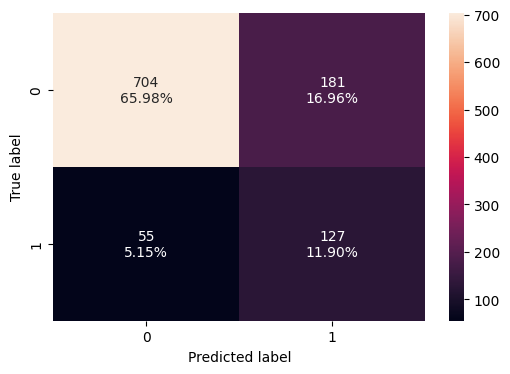

```python
#create a confusion matrix of the classifier's performance on the testing data
confusion_matrix_sklearn(tuning_random_forest_l, X_l_test,y_l_test)

tuned_random_forest_model_test_perf_l = model_performance_classification_sklearn(tuning_random_forest_l, X_l_test, y_l_test)
print("Testing performance \n",tuned_random_forest_model_test_perf_l)
```

**Observations:**

1. The model correctly identifies 127 buyers, which explains the high recall (69.8%).
2. However, 181 non-buyers are wrongly predicted as buyers, causing low precision (41.2%).
3. The moderate F1-score (0.52) shows imbalance between catching buyers and false alarms.
4. ROC-AUC (0.81) indicates good separation between buyers and non-buyers despite false positives

```
Training performance
    Accuracy    Recall  Precision        F1   ROC_AUC
0  0.772621  0.697802   0.403816  0.511581  0.823464
```

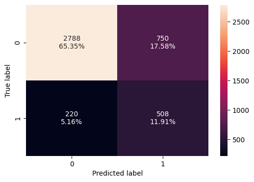

```python
#create a confusion matrix of the classifier's performance on the training data
confusion_matrix_sklearn(tuning_random_forest_l, X_l_train,y_l_train)

tuned_random_forest_model_train_perf_l = model_performance_classification_sklearn(tuning_random_forest_l, X_l_train, y_l_train)
print("Training performance \n",tuned_random_forest_model_train_perf_l)
```

**Observations:**

1. The model correctly predicts 508 buyers, maintaining strong recall (69.8%).
2. A high number of false positives (750) reduces precision to 40.4%.
3. F1-score (0.51) confirms moderate overall buyer prediction quality.
4. ROC-AUC (0.82) shows the model still distinguishes buyers well overall.

### **AdaBoost Classifier**

#### **For Mobile**

```python
# using function AdaBoostClassifier from sklearn to build model

ada_boost_m =AdaBoostClassifier(random_state=1)
ada_boost_m.fit(X_m_train, y_m_train)
```

```
AdaBoostClassifier(random_state=1)
```

##### **Confusion Matrix and Performance Check of Testing data - For Mobile**

```
Testing performance
    Accuracy    Recall  Precision        F1   ROC_AUC
0  0.863057  0.189744    0.72549  0.300813  0.817468
```

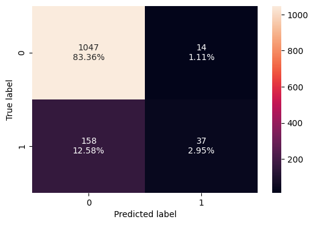

```python
#create a confusion matrix of the classifier's performance on the testing data
confusion_matrix_sklearn(ada_boost_m, X_m_test, y_m_test)

ada_boost_test_perf_m= model_performance_classification_sklearn(ada_boost_m, X_m_test, y_m_test)
print("Testing performance \n",ada_boost_test_perf_m)
```

**Observations:**

1. 1047 non-buyers are correctly predicted, which gives a high accuracy of 86 percent.
2. Only 37 buyers are correctly identified, while 158 buyers are missed, leading to a low recall of 19 percent.
3. Only 14 non-buyers are wrongly predicted as buyers, so precision is high at 73 percent.
4. Because many buyers are missed, the F1 score remains low at 0.30.
5. ROC score of 0.82 indicates good separation between buyers and non-buyers, but buyer prediction is conservative.

##### **Confusion Matrix and Performance Check of Training data - For Mobile**

```
Training performance
    Accuracy    Recall  Precision        F1   ROC_AUC
0  0.851254  0.133676   0.587571  0.217801  0.787507
```

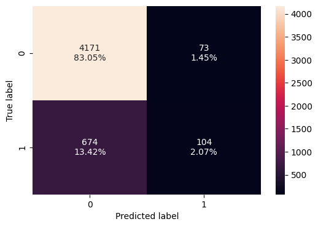

```python
#create a confusion matrix of the classifier's performance on the training data
confusion_matrix_sklearn(ada_boost_m, X_m_train, y_m_train)

ada_boost_train_perf_m = model_performance_classification_sklearn(ada_boost_m, X_m_train, y_m_train)
print("Training performance \n",ada_boost_train_perf_m)
```

**Observations:**

1. 4171 non-buyers are correctly predicted as non-buyers, which leads to a high accuracy of 85 percent.
2. 674 actual buyers are wrongly predicted as non-buyers, so the model misses most buyers, giving a very low recall of 13 percent.
3. Because the model predicts very few buyers incorrectly, precision is moderate at 59 percent, meaning predicted buyers are often correct.
4. The large gap between buyers found and buyers missed results in a low F1 score of 0.22.
5. ROC score of 0.79 shows the model can separate buyers and non-buyers reasonably well, but it avoids predicting buyers.

##### **AdaBoost With Hyperparameter Tuning - For Mobile**

```python
from sklearn.model_selection import GridSearchCV
from sklearn.metrics import make_scorer
# choosing type of classifier
tuning_ada_boost_m =AdaBoostClassifier(random_state=1)

# form grid of parameters to search in
grid_para ={
    "estimator": [ DecisionTreeClassifier(max_depth=1), DecisionTreeClassifier(max_depth=2), DecisionTreeClassifier(max_depth=3), ],
    "n_estimators": np.arange(20, 100, 20),
    "learning_rate": np.arange(0.2, 1.1, 0.2), }

# setting type of score used to evaluate performance search
scorer =make_scorer(f1_score) # runing GridSearch
grid_obj =GridSearchCV(tuning_ada_boost_m, grid_para, scoring=scorer, cv=5)
grid_obj = grid_obj.fit(X_m_train, y_m_train)

# setting classifer to best combination of parameters
tuning_ada_boost_m =grid_obj.best_estimator_

# fitting best decision tree to training data
tuning_ada_boost_m.fit(X_m_train, y_m_train)
```

```
AdaBoostClassifier(estimator=DecisionTreeClassifier(max_depth=3),
                   learning_rate=np.float64(1.0), n_estimators=np.int64(80),
                   random_state=1)
```

##### **Confusion Matrix and Performance Check After Tuning - For Mobile**

```
Testing performance
    Accuracy    Recall  Precision        F1   ROC_AUC
0  0.872611  0.379487   0.654867  0.480519  0.870947
```

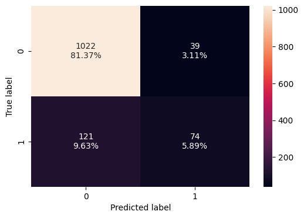

```python
#create a confusion matrix of the classifier's performance on the testing data
confusion_matrix_sklearn(tuning_ada_boost_m, X_m_test,y_m_test)

tuned_ada_boost_model_test_perf_m = model_performance_classification_sklearn(tuning_ada_boost_m, X_m_test, y_m_test)
print("Testing performance \n",tuned_ada_boost_model_test_perf_m)
```

**Observations:**

1. Confusion matrix shows 1022 non-buyers correctly predicted, 39 non-buyers wrongly predicted, 74 buyers correctly predicted, and 121 buyers wrongly predicted.
2. Accuracy of the model is 87.26 percent, showing stable performance on new data.
3. Recall is 37.95 percent, so most buyers are still not identified.
4. Precision is 65.49 percent, showing reasonable correctness of buyer predictions.
5. F1 score is 0.48 and ROC score is 0.87, confirming good separation but limited buyer detection.

```
Training performance
    Accuracy    Recall  Precision       F1   ROC_AUC
0  0.879132  0.362468   0.717557  0.48164  0.892276
```

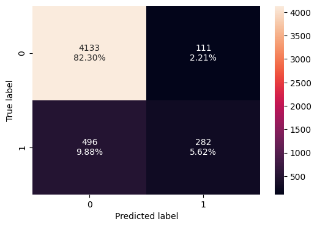

```python
#create a confusion matrix of the classifier's performance on the training data
confusion_matrix_sklearn(tuning_ada_boost_m, X_m_train,y_m_train)

tuned_ada_boost_model_train_perf_m = model_performance_classification_sklearn(tuning_ada_boost_m, X_m_train, y_m_train)
print("Training performance \n",tuned_ada_boost_model_train_perf_m)
```

**Observations:**

1. Confusion matrix shows 4133 non-buyers correctly predicted, 111 non-buyers wrongly predicted, 282 buyers correctly predicted, and 496 buyers wrongly predicted.
2. Accuracy of the model is 87.91 percent, showing overall good performance.
3. Recall is 36.26 percent, meaning many actual buyers are missed.
4. Precision is 71.76 percent, meaning predicted buyers are mostly correct.
5. F1 score is 0.48 and ROC score is 0.89, showing good class separation but weak buyer capture.

#### **For Laptop**

```python
# using function AdaBoostClassifier from sklearn to build model

ada_boost_l =AdaBoostClassifier(random_state=1)
ada_boost_l.fit(X_l_train, y_l_train)
```

```
AdaBoostClassifier(random_state=1)
```

##### **Confusion Matrix and Performance Check of Testing data - For Laptop**

```
Testing performance
    Accuracy   Recall  Precision        F1   ROC_AUC
0  0.842549  0.10989   0.769231  0.192308  0.798144
```

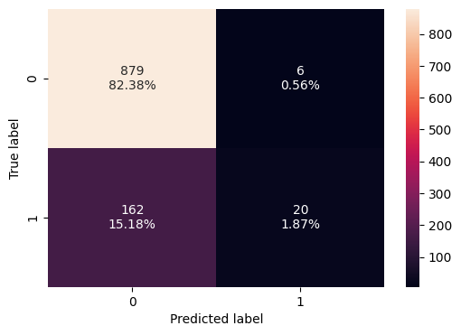

```python
#create a confusion matrix of the classifier's performance on the testing data
confusion_matrix_sklearn(ada_boost_l, X_l_test, y_l_test)

ada_boost_test_perf_l = model_performance_classification_sklearn(ada_boost_l, X_l_test, y_l_test)
print("Testing performance \n",ada_boost_test_perf_l)
```

**Observations:**

1. Confusion matrix shows 879 non-buyers correctly predicted and 20 buyers correctly predicted.
2. Accuracy is 84.25 percent, showing the model performs reasonably well on unseen data.
3. Recall is 10.99 percent, meaning most actual buyers are not identified by the model.
4. Precision is 76.92 percent, meaning when the model predicts a buyer, it is usually correct.
5. F1 score is 0.19 and ROC score is 0.80, indicating weak buyer detection but acceptable class separation.

##### **Confusion Matrix and Performance Check of Training data - For Laptop**

```
Training performance
    Accuracy    Recall  Precision        F1  ROC_AUC
0  0.842944  0.145604   0.688312  0.240363   0.7846
```

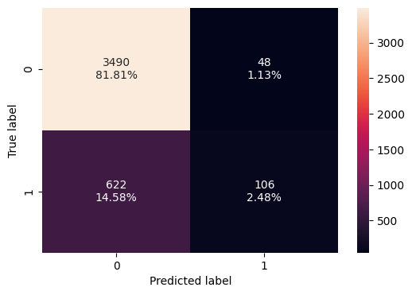

```python
#create a confusion matrix of the classifier's performance on the training data
confusion_matrix_sklearn(ada_boost_l, X_l_train, y_l_train)

ada_boost_train_perf_l = model_performance_classification_sklearn(ada_boost_l, X_l_train, y_l_train)
print("Training performance \n",ada_boost_train_perf_l)
```

**Observations:**

1. Confusion matrix shows 3490 non-buyers correctly predicted and 106 buyers correctly predicted.
2. Accuracy is 84.29 percent, showing consistent performance on training data.
3. Recall is 14.56 percent, meaning the model still misses many actual buyers.
4. Precision is 68.83 percent, showing moderate correctness in buyer predictions.
5. F1 score is 0.24 and ROC score is 0.78, indicating limited buyer identification with fair separation ability.

##### **AdaBoost With Hyperparameter Tuning - For Laptop**

```python
from sklearn.model_selection import GridSearchCV
from sklearn.metrics import make_scorer
# choosing type of classifier
tuning_ada_boost_l =AdaBoostClassifier(random_state=1)

# form grid of parameters to search in
grid_para ={
    "estimator": [ DecisionTreeClassifier(max_depth=1), DecisionTreeClassifier(max_depth=2), DecisionTreeClassifier(max_depth=3), ],
    "n_estimators": np.arange(20, 100, 20),
    "learning_rate": np.arange(0.2, 1.1, 0.2), }

# setting type of score used to evaluate performance search
scorer =make_scorer(f1_score) # runing GridSearch
grid_obj =GridSearchCV(tuning_ada_boost_l, grid_para, scoring=scorer, cv=5)
grid_obj = grid_obj.fit(X_l_train, y_l_train)

# setting classifer to best combination of parameters
tuning_ada_boost_l =grid_obj.best_estimator_

# fitting best decision tree to training data
tuning_ada_boost_l.fit(X_l_train, y_l_train)
```

```
AdaBoostClassifier(estimator=DecisionTreeClassifier(max_depth=3),
                   learning_rate=np.float64(1.0), n_estimators=np.int64(80),
                   random_state=1)
```

##### **Confusion Matrix and Performance Check After Tuning - For Laptop**

```
Testing performance
    Accuracy    Recall  Precision        F1  ROC_AUC
0  0.778819  0.697802   0.412338  0.518367  0.81472
```

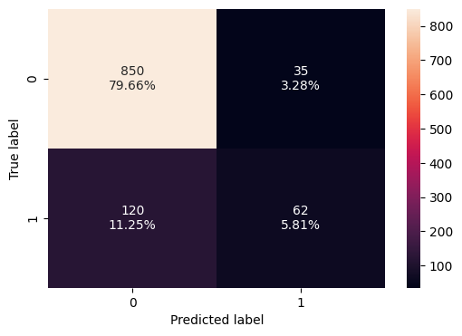

```python
#create a confusion matrix of the classifier's performance on the testing data
confusion_matrix_sklearn(tuning_ada_boost_l, X_l_test,y_l_test)

tuned_ada_boost_model_test_perf_l = model_performance_classification_sklearn(tuning_ada_boost_l, X_l_test, y_l_test)
print("Testing performance \n",tuned_random_forest_model_test_perf_l)
```

**Observations:**

```
Training performance
    Accuracy    Recall  Precision        F1   ROC_AUC
0  0.871074  0.385989   0.731771  0.505396  0.912676
```

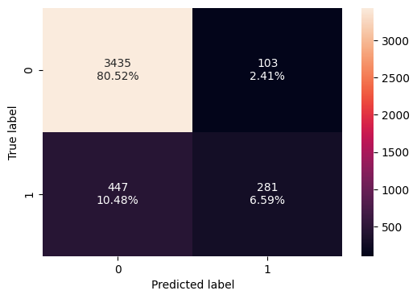

```python
#create a confusion matrix of the classifier's performance on the training data
confusion_matrix_sklearn(tuning_ada_boost_l, X_l_train,y_l_train)

tuned_ada_boost_model_train_perf_l = model_performance_classification_sklearn(tuning_ada_boost_l, X_l_train, y_l_train)
print("Training performance \n",tuned_ada_boost_model_train_perf_l)
```

**Observations:**

1. Confusion matrix shows 3435 non-buyers correctly predicted and 281 buyers correctly predicted.
2. Accuracy is 87.11 percent, showing strong performance on training data.
3. Recall is 38.60 percent, meaning many actual buyers are missed during training.
4. Precision is 73.18 percent, meaning predicted buyers are mostly correct.
5. F1 score is 0.51 and ROC score is 0.91, indicating strong class separation with moderate buyer identification.

### **Gradient Boosting Classifier**

#### **For Mobile**

```python
# using function GradientBoostingClassifier from sklearn to build model
gradient_boost_m =GradientBoostingClassifier(random_state=1)
gradient_boost_m.fit(X_m_train, y_m_train)
```

```
GradientBoostingClassifier(random_state=1)
```

##### **Confusion Matrix and Performance Check of Testing data - For Mobile**

```
Testing performance
    Accuracy    Recall  Precision    F1   ROC_AUC
0  0.886146  0.338462      0.825  0.48  0.869627
```

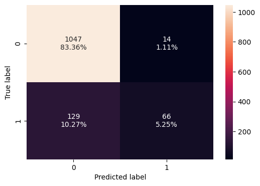

```python
#create a confusion matrix of the classifier's performance on the testing data
confusion_matrix_sklearn(gradient_boost_m, X_m_test, y_m_test)

gradient_boost_test_perf_m= model_performance_classification_sklearn(gradient_boost_m, X_m_test, y_m_test)
print("Testing performance \n",gradient_boost_test_perf_m)
```

**Observations:**

1. Confusion matrix shows 1047 non-buyers correctly predicted and 66 buyers correctly predicted.
2. Accuracy is 88.61 percent, showing strong overall prediction performance on test data.
3. Recall is 33.85 percent, meaning only one third of actual ticket buyers are identified.
4. Precision is 82.50 percent, meaning most predicted buyers are truly buyers.
5. F1 score is 0.48 and ROC score is 0.87, indicating good balance between buyer detection and class separation.

##### **Confusion Matrix and Performance Check of Training data - For Mobile**

```
Training performance
    Accuracy    Recall  Precision        F1   ROC_AUC
0  0.889685  0.339332   0.868421  0.487985  0.888958
```

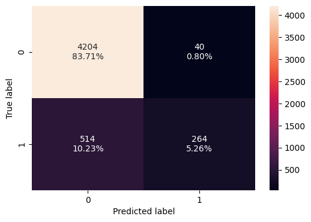

```python
#create a confusion matrix of the classifier's performance on the training data
confusion_matrix_sklearn(gradient_boost_m, X_m_train, y_m_train)

gradient_boost_train_perf_m = model_performance_classification_sklearn(gradient_boost_m, X_m_train, y_m_train)
print("Training performance \n",gradient_boost_train_perf_m)
```

**Observations:**

1. Confusion matrix shows 4204 non-buyers correctly predicted and 264 buyers correctly predicted.
2. Accuracy is 88.97 percent, showing consistent performance on training data.
3. Recall is 33.93 percent, meaning many actual buyers are still missed.
4. Precision is 86.84 percent, meaning predicted buyers are highly reliable.
5. F1 score is 0.49 and ROC score is 0.89, indicating strong class separation with moderate buyer identification.

##### **Gradient Boosting With Hyperparameter Tuning - For Mobile**

```python
# choosing type of classifier
tuning_gradient_boost_m =GradientBoostingClassifier(init=AdaBoostClassifier(random_state=1), random_state=1 )

# form grid of parameters to search in
grid_para ={
    "subsample": [0.7, 0.8, 0.9],
    "max_features": [0.8, 0.9, 1.0],
    "n_estimators": np.arange(20, 100, 20),
    "learning_rate": np.arange(0.2, 1.1, 0.2), }

# setting type of score used to evaluate performance search
scorer =make_scorer(f1_score) # running GridSearch
grid_obj =GridSearchCV(tuning_gradient_boost_m, grid_para, scoring=scorer, cv=5)
grid_obj =grid_obj.fit(X_m_train, y_m_train)

# Set classifer to best combination of parameters
tuning_gradient_boost_m =grid_obj.best_estimator_
# Fit best decision tree to training data
tuning_gradient_boost_m.fit(X_m_train, y_m_train)
```

```
GradientBoostingClassifier(init=AdaBoostClassifier(random_state=1),
                           learning_rate=np.float64(1.0), max_features=1.0,
                           n_estimators=np.int64(80), random_state=1,
                           subsample=0.9)
```

##### **Confusion Matrix and Performance Check After Tuning - For Mobile**

```
Testing performance
    Accuracy    Recall  Precision        F1   ROC_AUC
0  0.904459  0.620513   0.724551  0.668508  0.901254
```

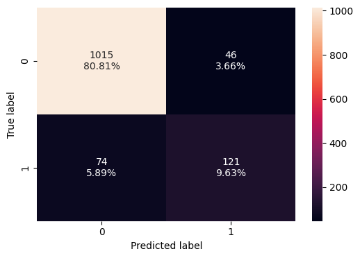

```python
#create a confusion matrix of the classifier's performance on the testing data
confusion_matrix_sklearn(tuning_gradient_boost_m, X_m_test,y_m_test)

tuned_gradient_boost_model_test_perf_m = model_performance_classification_sklearn(tuning_gradient_boost_m, X_m_test, y_m_test)
print("Testing performance \n",tuned_gradient_boost_model_test_perf_m)
```

**Observations:**

1. Confusion matrix shows 1015 non-buyers correctly predicted and 121 buyers correctly predicted.
2. Accuracy is 90.45 percent, showing strong overall performance on unseen data.
3. Recall is 62.05 percent, meaning most actual ticket buyers are identified.
4. Precision is 72.46 percent, meaning predicted buyers are mostly correct.
5. F1 score is 0.67 and ROC score is 0.90, indicating good balance and strong ability to separate buyers and non-buyers.

```
Training performance
    Accuracy    Recall  Precision        F1   ROC_AUC
0  0.966746  0.830334   0.948605  0.885538  0.986257
```

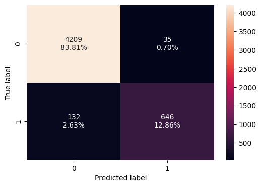

```python
#create a confusion matrix of the classifier's performance on the training data
confusion_matrix_sklearn(tuning_gradient_boost_m, X_m_train,y_m_train)

tuned_gradient_boost_model_train_perf_m = model_performance_classification_sklearn(tuning_gradient_boost_m, X_m_train, y_m_train)
print("Training performance \n",tuned_gradient_boost_model_train_perf_m)
```

**Observations:**

1. Confusion matrix shows 4209 non-buyers correctly predicted and 646 buyers correctly predicted.
2. Accuracy is 96.67 percent, indicating excellent fit on training data.
3. Recall is 83.03 percent, meaning most actual buyers are captured during training.
4. Precision is 94.87 percent, meaning predicted buyers are highly reliable.
5. F1 score is 0.89 and ROC score is 0.99, showing very strong buyer identification and class separation.

#### **For Laptop**

```python
# using function GradientBoostingClassifier from sklearn to build model
gradient_boost_l =GradientBoostingClassifier(random_state=1)
gradient_boost_l.fit(X_l_train, y_l_train)
```

```
GradientBoostingClassifier(random_state=1)
```

##### **Confusion Matrix and Performance Check of Testing data - For Laptop**

```
Testing performance
    Accuracy    Recall  Precision        F1   ROC_AUC
0  0.874414  0.384615    0.76087  0.510949  0.871326
```

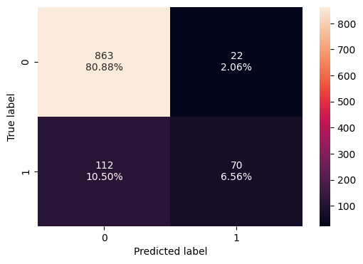

```python
#create a confusion matrix of the classifier's performance on the testing data
confusion_matrix_sklearn(gradient_boost_l, X_l_test, y_l_test)

gradient_boost_test_perf_l = model_performance_classification_sklearn(gradient_boost_l, X_l_test, y_l_test)
print("Testing performance \n",gradient_boost_test_perf_l)
```

**Observations:**

1. Confusion matrix shows 863 non-buyers correctly predicted and 70 buyers correctly predicted.
2. Accuracy is 87.44 percent, showing good overall prediction on test data.
3. Recall is 38.46 percent, meaning many actual buyers are still missed.
4. Precision is 76.09 percent, meaning most predicted buyers are correct.
5. F1 score is 0.51 and ROC score is 0.87, indicating moderate balance and good class separation.

##### **Confusion Matrix and Performance Check of Training data - For Laptop**

```
Training performance
    Accuracy    Recall  Precision        F1   ROC_AUC
0  0.889123  0.407967   0.876106  0.556701  0.911869
```

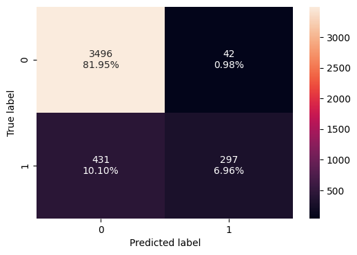

```python
#create a confusion matrix of the classifier's performance on the training data
confusion_matrix_sklearn(gradient_boost_l, X_l_train, y_l_train)

gradient_boost_train_perf_l = model_performance_classification_sklearn(gradient_boost_l, X_l_train, y_l_train)
print("Training performance \n",gradient_boost_train_perf_l)
```

**Observations:**

1. Confusion matrix shows 3496 non-buyers correctly predicted and 297 buyers correctly predicted.
2. Accuracy is 88.91 percent, indicating stable performance on training data.
3. Recall is 40.80 percent, showing limited ability to capture all buyers.
4. Precision is 87.61 percent, meaning predicted buyers are highly reliable.
5. F1 score is 0.56 and ROC score is 0.91, showing good separation between buyers and non-buyers.

##### **Gradient Boosting With Hyperparameter Tuning - For Laptop**

```python
# choosing type of classifier
tuning_gradient_boost_l =GradientBoostingClassifier(init=AdaBoostClassifier(random_state=1), random_state=1 )

# form grid of parameters to search in
grid_para ={
    "subsample": [0.7, 0.8, 0.9],
    "max_features": [0.8, 0.9, 1.0],
    "n_estimators": np.arange(20, 100, 20),
    "learning_rate": np.arange(0.2, 1.1, 0.2), }

# setting type of score used to evaluate performance search
scorer =make_scorer(f1_score) # running GridSearch
grid_obj =GridSearchCV(tuning_gradient_boost_l, grid_para, scoring=scorer, cv=5)
grid_obj =grid_obj.fit(X_l_train, y_l_train)

# Set classifer to best combination of parameters
tuning_gradient_boost_l =grid_obj.best_estimator_
# Fit best decision tree to training data
tuning_gradient_boost_l.fit(X_l_train, y_l_train)
```

```
GradientBoostingClassifier(init=AdaBoostClassifier(random_state=1),
                           learning_rate=np.float64(1.0), max_features=0.9,
                           n_estimators=np.int64(80), random_state=1,
                           subsample=0.9)
```

##### **Confusion Matrix and Performance Check After Tuning - For Laptop**

```
Testing performance
    Accuracy    Recall  Precision        F1   ROC_AUC
0  0.907216  0.659341   0.764331  0.707965  0.929087
```

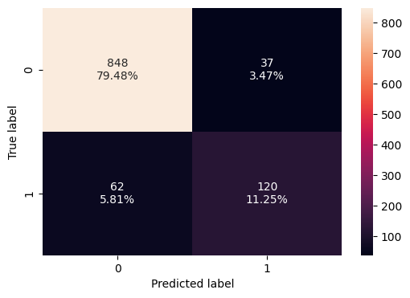

```python
#create a confusion matrix of the classifier's performance on the testing data
confusion_matrix_sklearn(tuning_gradient_boost_l, X_l_test,y_l_test)

tuned_gradient_boost_model_test_perf_l = model_performance_classification_sklearn(tuning_gradient_boost_l, X_l_test, y_l_test)
print("Testing performance \n",tuned_gradient_boost_model_test_perf_l)
```

**Observations:**

1. Confusion matrix shows 848 non-buyers correctly predicted and 120 buyers correctly predicted.
2. Accuracy is 90.72 percent, showing strong overall prediction on test data.
3. Recall is 65.93 percent, meaning the model identifies most actual ticket buyers.
4. Precision is 76.43 percent, meaning predicted buyers are mostly correct.
5. F1 score is 0.71 and ROC score is 0.93, indicating good balance and excellent separation between buyers and non-buyers.

```
Training performance
    Accuracy   Recall  Precision        F1   ROC_AUC
0  0.975856  0.89011   0.965723  0.926376  0.993521
```

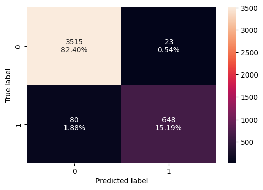

```python
#create a confusion matrix of the classifier's performance on the training data
confusion_matrix_sklearn(tuning_gradient_boost_l, X_l_train,y_l_train)

tuned_gradient_boost_model_train_perf_l = model_performance_classification_sklearn(tuning_gradient_boost_l, X_l_train, y_l_train)
print("Training performance \n",tuned_gradient_boost_model_train_perf_l)
```

**Observations:**

1. Confusion matrix shows 3515 non-buyers correctly predicted and 648 buyers correctly predicted.
2. Accuracy is 97.59 percent, showing very high performance on training data.
3. Recall is 89.01 percent, meaning most buyers are successfully captured.
4. Precision is 96.57 percent, meaning predicted buyers are highly accurate.
5. F1 score is 0.93 and ROC score is 0.99, indicating excellent model learning and class separation.

### **XGBoost Classifier**

#### **For Mobile**

```python
# using function XGBClassifier from xgboost to build model
xg_boost_m =XGBClassifier(eval_metric="logloss", random_state=1)
xg_boost_m.fit(X_m_train, y_m_train)
```

```
XGBClassifier(base_score=None, booster=None, callbacks=None,
              colsample_bylevel=None, colsample_bynode=None,
              colsample_bytree=None, device=None, early_stopping_rounds=None,
              enable_categorical=False, eval_metric='logloss',
              feature_types=None, feature_weights=None, gamma=None,
              grow_policy=None, importance_type=None,
              interaction_constraints=None, learning_rate=None, max_bin=None,
              max_cat_threshold=None, max_cat_to_onehot=None,
              max_delta_step=None, max_depth=None, max_leaves=None,
              min_child_weight=None, missing=nan, monotone_constraints=None,
              multi_strategy=None, n_estimators=None, n_jobs=None,
              num_parallel_tree=None, ...)
```

##### **Confusion Matrix and Performance Check of Testing data - For Mobile**

```
Testing performance
    Accuracy    Recall  Precision        F1   ROC_AUC
0  0.950637  0.723077   0.946309  0.819767  0.959869
```

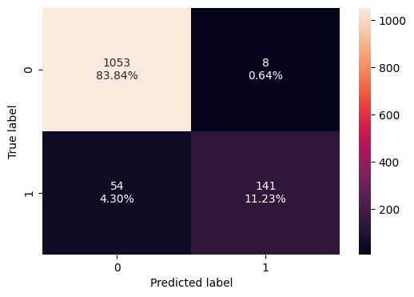

```python
#create a confusion matrix of the classifier's performance on the testing data
confusion_matrix_sklearn(xg_boost_m, X_m_test, y_m_test)

xg_boost_test_perf_m= model_performance_classification_sklearn(xg_boost_m, X_m_test, y_m_test)
print("Testing performance \n",xg_boost_test_perf_m)
```

**Observations:**

1. Confusion matrix shows 1053 non-buyers correctly predicted and 141 buyers correctly predicted.
2. Accuracy is 95.06 percent, showing very strong overall prediction on unseen mobile data.
3. Recall is 72.31 percent, meaning most actual mobile ticket buyers are identified, but some buyers are still missed.
4. Precision is 94.63 percent, meaning predicted buyers are mostly correct with very few false alarms.
5. F1 score is 0.82 and ROC score is 0.96, showing a good balance between precision and recall and excellent class separation.

##### **Confusion Matrix and Performance Check of Training data - For Mobile**

```
Training performance
    Accuracy   Recall  Precision        F1   ROC_AUC
0  0.997411  0.98329        1.0  0.991575  0.999967
```

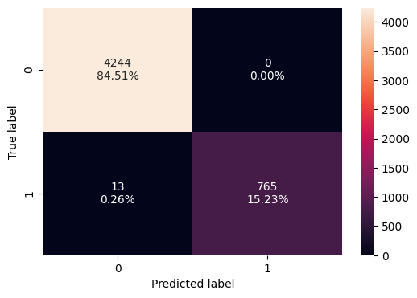

```python
#create a confusion matrix of the classifier's performance on the training data
confusion_matrix_sklearn(xg_boost_m, X_m_train, y_m_train)

xg_boost_train_perf_m = model_performance_classification_sklearn(xg_boost_m, X_m_train, y_m_train)
print("Training performance \n",xg_boost_train_perf_m)
```

**Observations:**

1. Confusion matrix shows 4244 non-buyers correctly predicted and 765 buyers correctly predicted.
2. Accuracy is 99.74 percent, indicating extremely high performance on training data.
3. Recall is 98.33 percent, meaning almost all mobile ticket buyers are correctly captured.
4. Precision is 100 percent, meaning every predicted buyer is actually a buyer in training data.
5. F1 score is 0.99 and ROC score is 1.00, indicating near-perfect learning and a strong sign of overfitting risk.

##### **XGBoost With Hyperparameter Tuning - For Mobile**

```python
# choosing type of classifier
tuning_xg_boost_m =XGBClassifier(eval_metric="logloss", random_state=1)
# form grid of parameters to search in
grid_para ={ "subsample": [0.6, 0.8], "scale_pos_weight": [1, 2], "gamma": [3, 5], "colsample_bytree": [0.6, 0.8], "colsample_bylevel": [0.6, 0.8], "n_estimators": [50, 100], "learning_rate": [0.1, 0.2], }
# setting type of score used to evaluate performance search
scorer =make_scorer(f1_score)

# run GridSearch
grid_obj =GridSearchCV(tuning_xg_boost_m, grid_para, scoring=scorer, cv=5)
grid_obj =grid_obj.fit(X_m_train, y_m_train)

# setting classifer to best combination of parameters
tuning_xg_boost_m = grid_obj.best_estimator_

# fitting best decision tree to training data
tuning_xg_boost_m.fit(X_m_train, y_m_train)
```

```
XGBClassifier(base_score=None, booster=None, callbacks=None,
              colsample_bylevel=0.6, colsample_bynode=None,
              colsample_bytree=0.8, device=None, early_stopping_rounds=None,
              enable_categorical=False, eval_metric='logloss',
              feature_types=None, feature_weights=None, gamma=3,
              grow_policy=None, importance_type=None,
              interaction_constraints=None, learning_rate=0.2, max_bin=None,
              max_cat_threshold=None, max_cat_to_onehot=None,
              max_delta_step=None, max_depth=None, max_leaves=None,
              min_child_weight=None, missing=nan, monotone_constraints=None,
              multi_strategy=None, n_estimators=100, n_jobs=None,
              num_parallel_tree=None, ...)
```

##### **Confusion Matrix and Performance Check After Tuning - For Mobile**

```
Testing performance
    Accuracy    Recall  Precision        F1   ROC_AUC
0  0.916401  0.620513   0.796053  0.697406  0.930114
```

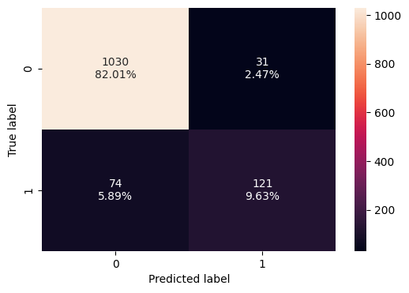

```python
#create a confusion matrix of the classifier's performance on the testing data
confusion_matrix_sklearn(tuning_xg_boost_m, X_m_test,y_m_test)

tuned_xg_boost_model_test_perf_m = model_performance_classification_sklearn(tuning_xg_boost_m, X_m_test, y_m_test)
print("Testing performance \n",tuned_xg_boost_model_test_perf_m)
```

**Observations:**

1. Confusion matrix shows 1030 non-buyers correctly predicted and 121 buyers correctly predicted.
2. Accuracy is 91.64 percent, showing strong overall performance on unseen mobile data.
3. Recall is 62.05 percent, meaning a moderate number of actual buyers are identified, but some buyers are still missed.
4. Precision is 79.61 percent, indicating most predicted buyers are correct with limited false predictions.
5. F1 score is 0.70 and ROC score is 0.93, showing a good balance between buyer detection and prediction reliability.

```
Training performance
    Accuracy    Recall  Precision        F1   ROC_AUC
0  0.944444  0.753213   0.870728  0.807719  0.971761
```

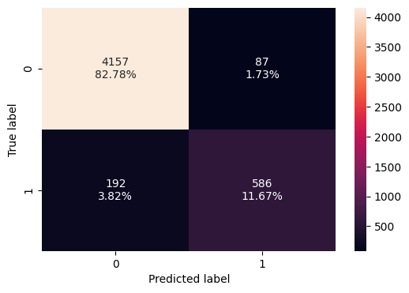

```python
#create a confusion matrix of the classifier's performance on the training data
confusion_matrix_sklearn(tuning_xg_boost_m, X_m_train,y_m_train)

tuned_xg_boost_model_train_perf_m = model_performance_classification_sklearn(tuning_xg_boost_m, X_m_train, y_m_train)
print("Training performance \n",tuned_xg_boost_model_train_perf_m)
```

**Observations:**

1. Confusion matrix shows 4157 non-buyers correctly predicted and 586 buyers correctly predicted.
2. Accuracy is 94.44 percent, indicating very strong learning on training data.
3. Recall is 75.32 percent, meaning most buyers in training data are successfully identified.
4. Precision is 87.07 percent, showing high confidence when the model predicts a buyer.
5. F1 score is 0.81 and ROC score is 0.97, indicating excellent separation between buyers and non-buyers with controlled overfitting.

#### **For Laptop**

```python
# using function XGBClassifier from xgboost to build model
xg_boost_l =XGBClassifier(eval_metric="logloss", random_state=1)
xg_boost_l.fit(X_l_train, y_l_train)
```

```
XGBClassifier(base_score=None, booster=None, callbacks=None,
              colsample_bylevel=None, colsample_bynode=None,
              colsample_bytree=None, device=None, early_stopping_rounds=None,
              enable_categorical=False, eval_metric='logloss',
              feature_types=None, feature_weights=None, gamma=None,
              grow_policy=None, importance_type=None,
              interaction_constraints=None, learning_rate=None, max_bin=None,
              max_cat_threshold=None, max_cat_to_onehot=None,
              max_delta_step=None, max_depth=None, max_leaves=None,
              min_child_weight=None, missing=nan, monotone_constraints=None,
              multi_strategy=None, n_estimators=None, n_jobs=None,
              num_parallel_tree=None, ...)
```

##### **Confusion Matrix and Performance Check of Testing data - For Laptop**

```
Testing performance
    Accuracy    Recall  Precision        F1   ROC_AUC
0  0.969072  0.835165   0.980645  0.902077  0.992631
```

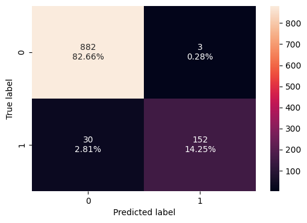

```python
#create a confusion matrix of the classifier's performance on the testing data
confusion_matrix_sklearn(xg_boost_l, X_l_test, y_l_test)

xg_boost_test_perf_l = model_performance_classification_sklearn(xg_boost_l, X_l_test, y_l_test)
print("Testing performance \n",xg_boost_test_perf_l)
```

**Observations:**

1. Confusion matrix shows 882 non-buyers correctly predicted and 152 buyers correctly predicted.
2. Accuracy is 96.91 percent, showing excellent overall performance on test data.
3. Recall is 83.52 percent, meaning most actual ticket buyers are identified correctly.
4. Precision is 98.06 percent, meaning predicted buyers are almost always correct.
5. F1 score is 0.90 and ROC score is 0.99, indicating very strong balance and excellent class separation.

##### **Confusion Matrix and Performance Check of Training data - For Laptop**

```
Training performance
    Accuracy    Recall  Precision        F1  ROC_AUC
0  0.999531  0.997253        1.0  0.998624      1.0
```

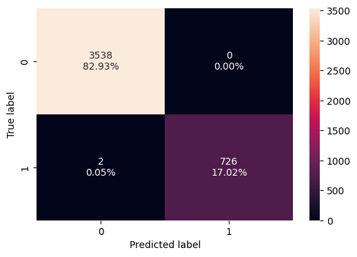

```python
#create a confusion matrix of the classifier's performance on the training data
confusion_matrix_sklearn(xg_boost_l, X_l_train, y_l_train)

xg_boost_train_perf_l = model_performance_classification_sklearn(xg_boost_l, X_l_train, y_l_train)
print("Training performance \n",xg_boost_train_perf_l)
```

**Observations:**

1. Confusion matrix shows 3538 non-buyers correctly predicted and 726 buyers correctly predicted.
2. Accuracy is 99.95 percent, showing near-perfect performance on training data.
3. Recall is 99.73 percent, meaning almost all buyers are captured.
4. Precision is 100 percent, meaning every predicted buyer is correct.
5. F1 score is 0.99 and ROC score is 1.00, indicating perfect learning and very high risk of overfitting.

##### **XGBoost With Hyperparameter Tuning - For Laptop**

```python
# choosing type of classifier
tuning_xg_boost_l =XGBClassifier(eval_metric="logloss", random_state=1)
# form grid of parameters to search in
grid_para ={ "subsample": [0.6, 0.8], "scale_pos_weight": [1, 2], "gamma": [3, 5], "colsample_bytree": [0.6, 0.8], "colsample_bylevel": [0.6, 0.8], "n_estimators": [50, 100], "learning_rate": [0.1, 0.2], }
# setting type of score used to evaluate performance search
scorer =make_scorer(f1_score)

# run GridSearch
grid_obj =GridSearchCV(tuning_xg_boost_l, grid_para, scoring=scorer, cv=5)
grid_obj =grid_obj.fit(X_l_train, y_l_train)

# setting classifer to best combination of parameters
tuning_xg_boost_l = grid_obj.best_estimator_

# fitting best decision tree to training data
tuning_xg_boost_l.fit(X_l_train, y_l_train)
```

```
XGBClassifier(base_score=None, booster=None, callbacks=None,
              colsample_bylevel=0.8, colsample_bynode=None,
              colsample_bytree=0.8, device=None, early_stopping_rounds=None,
              enable_categorical=False, eval_metric='logloss',
              feature_types=None, feature_weights=None, gamma=3,
              grow_policy=None, importance_type=None,
              interaction_constraints=None, learning_rate=0.2, max_bin=None,
              max_cat_threshold=None, max_cat_to_onehot=None,
              max_delta_step=None, max_depth=None, max_leaves=None,
              min_child_weight=None, missing=nan, monotone_constraints=None,
              multi_strategy=None, n_estimators=100, n_jobs=None,
              num_parallel_tree=None, ...)
```

##### **Confusion Matrix and Performance Check After Tuning - For Laptop**

```
Testing performance
    Accuracy    Recall  Precision        F1   ROC_AUC
0  0.910965  0.648352   0.791946  0.712991  0.947197
```

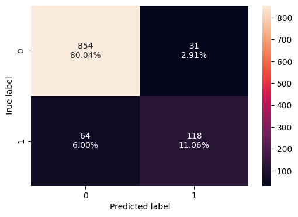

```python
#create a confusion matrix of the classifier's performance on the testing data
confusion_matrix_sklearn(tuning_xg_boost_l, X_l_test,y_l_test)

tuned_xg_boost_model_test_perf_l = model_performance_classification_sklearn(tuning_xg_boost_l, X_l_test, y_l_test)
print("Testing performance \n",tuned_xg_boost_model_test_perf_l)
```

**Observations:**

1. Confusion matrix shows 854 non-buyers correctly predicted and 118 buyers correctly predicted.
2. Accuracy is 91.10 percent, showing strong overall prediction performance on new laptop data.
3. Recall is 64.84 percent, meaning the model captures a fair number of actual laptop ticket buyers but still misses some.
4. Precision is 79.19 percent, indicating that most predicted buyers are truly buyers with limited false alarms.
5. F1 score is 0.71 and ROC score is 0.95, showing a good balance between buyer detection and class separation.

```
Training performance
    Accuracy    Recall  Precision        F1   ROC_AUC
0  0.951008  0.828297   0.877729  0.852297  0.984708
```

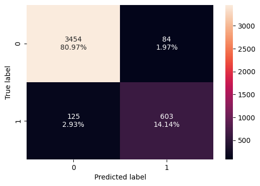

```python
#create a confusion matrix of the classifier's performance on the training data
confusion_matrix_sklearn(tuning_xg_boost_l, X_l_train,y_l_train)

tuned_xg_boost_model_train_perf_l = model_performance_classification_sklearn(tuning_xg_boost_l, X_l_train, y_l_train)
print("Training performance \n",tuned_xg_boost_model_train_perf_l)
```

**Observations:**

1. Confusion matrix shows 3454 non-buyers correctly predicted and 603 buyers correctly predicted.
2. Accuracy is 95.10 percent, indicating excellent learning on the training data.
3. Recall is 82.83 percent, meaning most actual laptop ticket buyers are correctly identified.
4. Precision is 87.77 percent, showing high confidence when predicting a buyer.
5. F1 score is 0.85 and ROC score is 0.98, indicating strong model stability and minimal overfitting.

## **Model Comparison and Final Model Selection**

### **For Mobile**

```python
# creating a data frame with summary of model performance on testing data set
perf_test_mobile =pd.concat(
    [
         dtree_model_test_perf_m.T,
         tuned_dtree_model_test_perf_m.T,
         bagging_model_test_perf_m.T,
         tuned_bagging_model_test_perf_m.T,
         random_forest_test_perf_m.T,
         tuned_random_forest_model_test_perf_m.T,
         ada_boost_test_perf_m.T,
         tuned_ada_boost_model_test_perf_m.T,
         gradient_boost_test_perf_m.T,
         tuned_gradient_boost_model_test_perf_m.T,
         xg_boost_test_perf_m.T,
         tuned_xg_boost_model_test_perf_m.T
         ],
    axis=1
)

perf_test_mobile.columns =[
     "Decision Tree mobile",
     "Tuned Decision Tree mobile",
     "Bagging mobile",
     "Tuned Bagging mobile",
     "Random Forest mobile",
     "Tuned Random Forest mobile",
     "AdaBoost mobile",
     "Tuned AdaBoost mobile",
     "Gradient Boosting mobile",
     "Tuned Gradient Boosting mobile",
     "XGBoost mobile",
     "Tuned XGBoost mobile"
     ]
print("The Model Performance Comparison for Testing Data Set - For Mobile:")
perf_test_mobile
```

```
The Model Performance Comparison for Testing Data Set - For Mobile:
```

|  | Decision Tree mobile | Tuned Decision Tree mobile | Bagging mobile | Tuned Bagging mobile | Random Forest mobile | Tuned Random Forest mobile | AdaBoost mobile | Tuned AdaBoost mobile | Gradient Boosting mobile | Tuned Gradient Boosting mobile | XGBoost mobile | Tuned XGBoost mobile |
| --- | --- | --- | --- | --- | --- | --- | --- | --- | --- | --- | --- | --- |
| Accuracy | 0.928344 | 0.790605 | 0.948248 | 0.960987 | 0.960987 | 0.771497 | 0.863057 | 0.872611 | 0.886146 | 0.904459 | 0.950637 | 0.916401 |
| Recall | 0.733333 | 0.625641 | 0.702564 | 0.769231 | 0.748718 | 0.702564 | 0.189744 | 0.379487 | 0.338462 | 0.620513 | 0.723077 | 0.620513 |
| Precision | 0.790055 | 0.391026 | 0.951389 | 0.974026 | 1.000000 | 0.374317 | 0.725490 | 0.654867 | 0.825000 | 0.724551 | 0.946309 | 0.796053 |
| F1 | 0.760638 | 0.481262 | 0.808260 | 0.859599 | 0.856305 | 0.488414 | 0.300813 | 0.480519 | 0.480000 | 0.668508 | 0.819767 | 0.697406 |
| ROC_AUC | 0.848759 | 0.787612 | 0.963423 | 0.988407 | 0.986597 | 0.827154 | 0.817468 | 0.870947 | 0.869627 | 0.901254 | 0.959869 | 0.930114 |

```python
# creating a data frame with summary of model performance on train data set
perf_train_mobile =pd.concat(
    [
         dtree_model_train_perf_m.T,
         tuned_dtree_model_train_perf_m.T,
         bagging_model_train_perf_m.T,
         tuned_bagging_model_train_perf_m.T,
         random_forest_train_perf_m.T,
         tuned_random_forest_model_train_perf_m.T,
         ada_boost_train_perf_m.T,
         tuned_ada_boost_model_train_perf_m.T,
         gradient_boost_train_perf_m.T,
         tuned_gradient_boost_model_train_perf_m.T,
         xg_boost_train_perf_m.T,
         tuned_xg_boost_model_train_perf_m.T
         ],
    axis=1
)

perf_train_mobile.columns =[
     "Decision Tree mobile",
     "Tuned Decision Tree mobile",
     "Bagging mobile",
     "Tuned Bagging mobile",
     "Random Forest mobile",
     "Tuned Random Forest mobile",
     "AdaBoost mobile",
     "Tuned AdaBoost mobile",
     "Gradient Boosting mobile",
     "Tuned Gradient Boosting mobile",
     "XGBoost mobile",
     "Tuned XGBoost mobile"
     ]
print("The Model Performance Comparison for Training Data Set - For Mobile:")
perf_train_mobile
```

```
The Model Performance Comparison for Training Data Set - For Mobile:
```

|  | Decision Tree mobile | Tuned Decision Tree mobile | Bagging mobile | Tuned Bagging mobile | Random Forest mobile | Tuned Random Forest mobile | AdaBoost mobile | Tuned AdaBoost mobile | Gradient Boosting mobile | Tuned Gradient Boosting mobile | XGBoost mobile | Tuned XGBoost mobile |
| --- | --- | --- | --- | --- | --- | --- | --- | --- | --- | --- | --- | --- |
| Accuracy | 1.0 | 0.793907 | 0.995221 | 1.0 | 1.0 | 0.762644 | 0.851254 | 0.879132 | 0.889685 | 0.966746 | 0.997411 | 0.944444 |
| Recall | 1.0 | 0.632391 | 0.970437 | 1.0 | 1.0 | 0.695373 | 0.133676 | 0.362468 | 0.339332 | 0.830334 | 0.983290 | 0.753213 |
| Precision | 1.0 | 0.396454 | 0.998677 | 1.0 | 1.0 | 0.361631 | 0.587571 | 0.717557 | 0.868421 | 0.948605 | 1.000000 | 0.870728 |
| F1 | 1.0 | 0.487370 | 0.984355 | 1.0 | 1.0 | 0.475814 | 0.217801 | 0.481640 | 0.487985 | 0.885538 | 0.991575 | 0.807719 |
| ROC_AUC | 1.0 | 0.783525 | 0.999959 | 1.0 | 1.0 | 0.813568 | 0.787507 | 0.892276 | 0.888958 | 0.986257 | 0.999967 | 0.971761 |

### **Laptop**

```python
# creating a data frame with summary of model performance on testing data set
perf_test_laptop =pd.concat(
    [
         dtree_model_test_perf_l.T,
         tuned_dtree_model_test_perf_l.T,
         bagging_model_test_perf_l.T,
         tuned_bagging_model_test_perf_l.T,
         random_forest_test_perf_l.T,
         tuned_random_forest_model_test_perf_l.T,
         ada_boost_test_perf_l.T,
         tuned_ada_boost_model_test_perf_l.T,
         gradient_boost_test_perf_l.T,
         tuned_gradient_boost_model_test_perf_l.T,
         xg_boost_test_perf_l.T,
         tuned_xg_boost_model_test_perf_l.T
         ],
    axis=1
)

perf_test_laptop.columns =[
     "Decision Tree laptop",
     "Tuned Decision Tree laptop",
     "Bagging laptop",
     "Tuned Bagging laptop",
     "Random Forest laptop",
     "Tuned Random Forest laptop",
     "AdaBoost laptop",
     "Tuned AdaBoost laptop",
     "Gradient Boosting laptop",
     "Tuned Gradient Boosting laptop",
     "XGBoost laptop",
     "Tuned XGBoost laptop"
     ]
print("The Model Performance Comparison for Testing Data Set - For Laptop:")
perf_test_laptop
```

```
The Model Performance Comparison for Testing Data Set - For Laptop:
```

|  | Decision Tree laptop | Tuned Decision Tree laptop | Bagging laptop | Tuned Bagging laptop | Random Forest laptop | Tuned Random Forest laptop | AdaBoost laptop | Tuned AdaBoost laptop | Gradient Boosting laptop | Tuned Gradient Boosting laptop | XGBoost laptop | Tuned XGBoost laptop |
| --- | --- | --- | --- | --- | --- | --- | --- | --- | --- | --- | --- | --- |
| Accuracy | 0.938144 | 0.669166 | 0.938144 | 0.969072 | 0.961575 | 0.778819 | 0.842549 | 0.854733 | 0.874414 | 0.907216 | 0.969072 | 0.910965 |
| Recall | 0.835165 | 0.785714 | 0.835165 | 0.846154 | 0.785714 | 0.697802 | 0.109890 | 0.340659 | 0.384615 | 0.659341 | 0.835165 | 0.648352 |
| Precision | 0.808511 | 0.312910 | 0.808511 | 0.968553 | 0.986207 | 0.412338 | 0.769231 | 0.639175 | 0.760870 | 0.764331 | 0.980645 | 0.791946 |
| F1 | 0.821622 | 0.447574 | 0.821622 | 0.903226 | 0.874618 | 0.518367 | 0.192308 | 0.444444 | 0.510949 | 0.707965 | 0.902077 | 0.712991 |
| ROC_AUC | 0.897243 | 0.758872 | 0.897243 | 0.994102 | 0.993956 | 0.814720 | 0.798144 | 0.871391 | 0.871326 | 0.929087 | 0.992631 | 0.947197 |

```python
# creating a data frame with summary of model performance on train data set
perf_train_laptop =pd.concat(
    [
         dtree_model_train_perf_l.T,
         tuned_dtree_model_train_perf_l.T,
         bagging_model_train_perf_l.T,
         tuned_bagging_model_train_perf_l.T,
         random_forest_train_perf_l.T,
         tuned_random_forest_model_train_perf_l.T,
         ada_boost_train_perf_l.T,
         tuned_ada_boost_model_train_perf_l.T,
         gradient_boost_train_perf_l.T,
         tuned_gradient_boost_model_train_perf_l.T,
         xg_boost_train_perf_l.T,
         tuned_xg_boost_model_train_perf_l.T
         ],
    axis=1
)

perf_train_laptop.columns =[
     "Decision Tree laptop",
     "Tuned Decision Tree laptop",
     "Bagging laptop",
     "Tuned Bagging laptop",
     "Random Forest laptop",
     "Tuned Random Forest laptop",
     "AdaBoost laptop",
     "Tuned AdaBoost laptop",
     "Gradient Boosting laptop",
     "Tuned Gradient Boosting laptop",
     "XGBoost laptop",
     "Tuned XGBoost laptop"
     ]
print("The Model Performance Comparison for Training Data Set - For Laptop:")
perf_train_laptop
```

```
The Model Performance Comparison for Training Data Set - For Laptop:
```

|  | Decision Tree laptop | Tuned Decision Tree laptop | Bagging laptop | Tuned Bagging laptop | Random Forest laptop | Tuned Random Forest laptop | AdaBoost laptop | Tuned AdaBoost laptop | Gradient Boosting laptop | Tuned Gradient Boosting laptop | XGBoost laptop | Tuned XGBoost laptop |
| --- | --- | --- | --- | --- | --- | --- | --- | --- | --- | --- | --- | --- |
| Accuracy | 1.0 | 0.686357 | 1.0 | 1.0 | 1.0 | 0.772621 | 0.842944 | 0.871074 | 0.889123 | 0.975856 | 0.999531 | 0.951008 |
| Recall | 1.0 | 0.810440 | 1.0 | 1.0 | 1.0 | 0.697802 | 0.145604 | 0.385989 | 0.407967 | 0.890110 | 0.997253 | 0.828297 |
| Precision | 1.0 | 0.329609 | 1.0 | 1.0 | 1.0 | 0.403816 | 0.688312 | 0.731771 | 0.876106 | 0.965723 | 1.000000 | 0.877729 |
| F1 | 1.0 | 0.468626 | 1.0 | 1.0 | 1.0 | 0.511581 | 0.240363 | 0.505396 | 0.556701 | 0.926376 | 0.998624 | 0.852297 |
| ROC_AUC | 1.0 | 0.797004 | 1.0 | 1.0 | 1.0 | 0.823464 | 0.784600 | 0.912676 | 0.911869 | 0.993521 | 1.000000 | 0.984708 |

**Observations:**

## **Overall Insights & Recommendations**

### **Recommendations**

1. Focus marketing campaigns more on laptop users, as they show higher purchase completion rates.
2. Use XGBoost as the final prediction model to identify high-intent customers accurately.
3. For mobile users, improve user experience and checkout flow to reduce drop-offs and increase conversions.
4. Target predicted buyers with personalized offers, reminders, or discounts to maximize ticket sales.
5. Continuously monitor model performance on new data to avoid overfitting and maintain accuracy over time.